# UnitE-wk4-Comparing groups and calculating estimates

Lecturer: Philip Leftwich, Module: UEA BIO 5023Y

# Introduction

Week 2 introduced the Selfed and Crossed Maize plants from Darwin’s 1876 book:

*The effects of cross and self-fertilisation in the vegetable kingdom*

In Week 2 we were first introduced to the concept of ANOVA as a linear model and we effectively worked out there was a significant difference between the mean height of selfed and crossed plants.

This week we are going to re-visit that data (the dataset is in both your Wk 2 and Wk3 projects so either workspace will do), and re-investigate it with an investigation of:

- Paired data
- Estimating confidence intervals

## Task 1 : Load the tidyverse and read in the darwin dataset

In today’s example we are going to revisit our model on heights and breeding type *height ~ type* and add in the fact that *each pair* represents paired offspring one the result of selfing, the other the result of crossing *height~type+pair*.

Once we have a model we are happy with, we will look at making confidence intervals to test *effect sizes*.

## TASK 2: Pivot the data from wide to long, set type and pair as factors, set the intercept to type = Self

```r
darwin <- darwin %>%
    pivot_longer(cols=c("Self":"Cross"),
                 names_to="type",
                 values_to="height") %>%
  mutate(type=factor(type,
                     levels=c("Self",
                              "Cross"))) %>%
  mutate(pair=factor(pair))
```

# Paired T-tests

## TASK 3 Write a linear model function that includes type & pair

By including pair (as a predictor variable) in our model (along with type) we are including the variance which is explained by the genotype of *at least one* of the plant’s parents

e.g. selfed plant from pair 1 is an inbred plant from parent 1 crossed plant has one parent as parent 1 and was outbred to have one other parent.

This is now the equivalent of a *paired t-test*. As the estimate of height difference now excludes any variance accounted for by the pairs.

```
##
## Call:
## lm(formula = height ~ type + pair, data = darwin)
##
## Residuals:
##     Min      1Q  Median      3Q     Max
## -5.4958 -0.9021  0.0000  0.9021  5.4958
##
## Coefficients:
##             Estimate Std. Error t value Pr(>|t|)
## (Intercept)  19.1292     2.4364   7.851  1.7e-06 ***
## typeCross     2.6167     1.2182   2.148   0.0497 *
## pair2        -4.2500     3.3362  -1.274   0.2234
## pair3         0.0625     3.3362   0.019   0.9853
## pair4         0.5625     3.3362   0.169   0.8685
## pair5        -1.6875     3.3362  -0.506   0.6209
## pair6        -0.3750     3.3362  -0.112   0.9121
## pair7        -0.0625     3.3362  -0.019   0.9853
## pair8        -2.6250     3.3362  -0.787   0.4445
## pair9        -3.0625     3.3362  -0.918   0.3742
## pair10       -0.6250     3.3362  -0.187   0.8541
## pair11       -0.6875     3.3362  -0.206   0.8397
## pair12       -0.9375     3.3362  -0.281   0.7828
## pair13       -3.0000     3.3362  -0.899   0.3837
## pair14       -1.1875     3.3362  -0.356   0.7272
## pair15       -5.4375     3.3362  -1.630   0.1254
## ---
## Signif. codes:  0 '***' 0.001 '**' 0.01 '*' 0.05 '.' 0.1 ' ' 1
##
## Residual standard error: 3.336 on 14 degrees of freedom
## Multiple R-squared:  0.469,  Adjusted R-squared:  -0.09997
## F-statistic: 0.8243 on 15 and 14 DF,  p-value: 0.6434
```

**Q. What can we interpret from our summary(model)**

Well it looks as though when you include variance explained by pairing, the type Cross/Inbred is still significant.

However none of the pair groups appear to significantly alter the mean height of plants.

On average **within** each pair the crossed plant is taller than the selfed plant. There is not a difference in the average height of plants **between** different pairs.

Rather than look at each estimate in turn we can collapse and summarise these differences by running `summary(aov())` on the model

```r
summary(aov(model))
```

```
##             Df Sum Sq Mean Sq F value Pr(>F)
## type         1  51.35   51.35   4.614 0.0497 *
## pair        14  86.26    6.16   0.554 0.8597
## Residuals   14 155.82   11.13
## ---
## Signif. codes:  0 '***' 0.001 '**' 0.01 '*' 0.05 '.' 0.1 ' ' 1
```

This seems to be back up our observation that pair does not significantly affect the mean height, while type does.

At this point we can *reject* a hypothesis that the means of the crossed and self plants are equal within each pair.

However we *cannot* reject a hypothesis that the mean heights between the different pairs of plants are equal.

## Plotting our estimated means

# Confidence intervals of the mean

Let’s start by calculating the 95% Confidence Intervals of our two means.

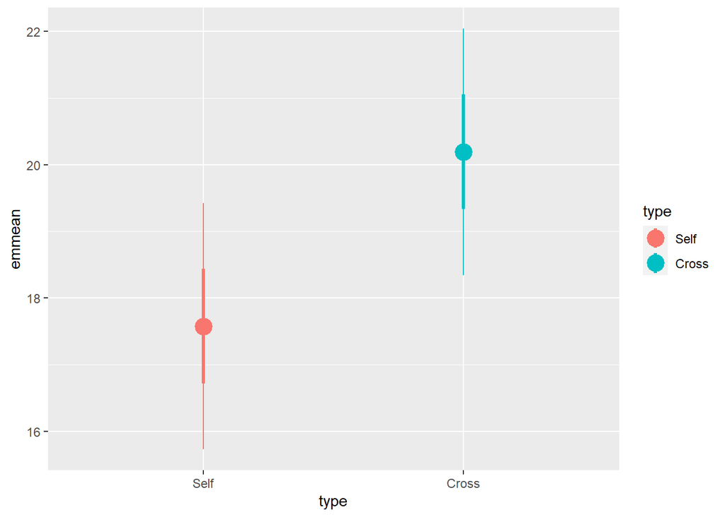

Thick lines represent the standard error (66% Confidence intervals), thin line are the 95% Confidence intervals

```r
library(emmeans) # A handy package for estimating means from the fit of our model

estimates <- emmeans(model, specs="type") ### here it will take the average of the values across all the pairs to calculate means for type

 estimates %>%
   as_tibble %>% ### emmeans outputs a grid by default, but can easily                       be changed
   ggplot(aes(x=type,
            y=emmean,
            colour=type))+
    geom_pointrange(aes(ymin=lower.CL,
                        ymax=upper.CL))+
    geom_pointrange(aes(ymin=emmean-SE,
                        ymax=emmean+SE),
                    size=1.2)
```

This would be a good way to visually report our estimates of the means. But as you can see neither Standard errors of the means *or* 95% Confidence intervals makes it obvious whether this difference is significant at *P* <0.05. Or what the effect size is of our statistical test.

# Effect sizes

## Calculate Confidence Intervals

So we already know which variables are significantly affecting the mean. However we are also interested in understanding the **effect size**.

The summary fit of our model provides the Standard Error of the mean differences for each fitted slope.

We also know that if we have an approximately normal distribution to the errors of our model then should be able to calculate 95% CI as (2 x SE).

**These are the 95% CI of the average difference between treatments, so these are perfectly complementary to the 5%** *P* **-value that is our benchmark for significance**

## TASK 4 Use broom::tidy() to force your model summary into a dataframe format, then use mutate to calculate the upper & lower CI for each estimate

```r
tidymodel1 <- broom::tidy(model) %>%
  mutate(lwr=((estimate-(std.error*2))),
    upr=(estimate+(std.error*2)))
```

If we draw a graph plotting an estimate as a point, and lines with lengths equivalent to 2* the Standard Error then we get whether an estimate mean is significantly different from the intercept at *P* < 0.05. According to the Normal (Z) distribution.

If set this to 3 * the Standard Error then this would be *P* < 0.01.

## TASK 5 Plot the 95% CI of the estimates against the Intercept.

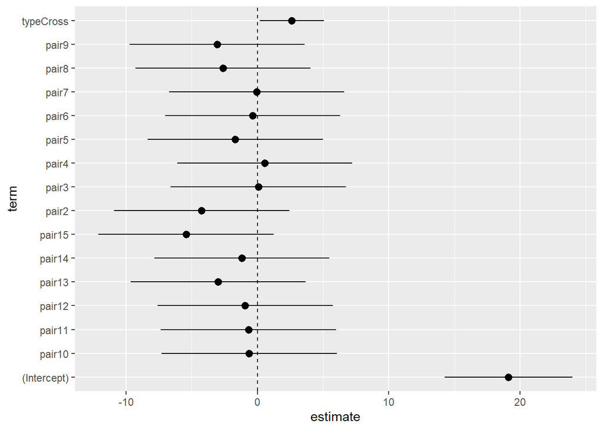

Anything which crosses the 0 is not significantly different at P<0.05 from the mean calculated for the Intercept

```r
tidymodel1 %>%
ggplot(aes(x=estimate,
           y=term))+
  geom_pointrange(aes(xmin=lwr,
                      xmax=upr))+
  geom_vline(xintercept=0,
             linetype="dashed")
```

Here we can confidently see that just like our summary output no estimate is significantly different from the *intercept* except **type**.

Luckily we don’t have to calculate confidence intervals by hand like this every time. Instead we can use a shortcut in the tidy() function by specifying the argument `conf.int=T`

```r
tidymodel2 <- broom::tidy(model, conf.int=T)
tidymodel2[2,] ## only pull out row 2
```

```
## # A tibble: 1 x 7
##   term      estimate std.error statistic p.value conf.low conf.high
##   <chr>        <dbl>     <dbl>     <dbl>   <dbl>    <dbl>     <dbl>
## 1 typeCross     2.62      1.22      2.15  0.0497  0.00390      5.23
```

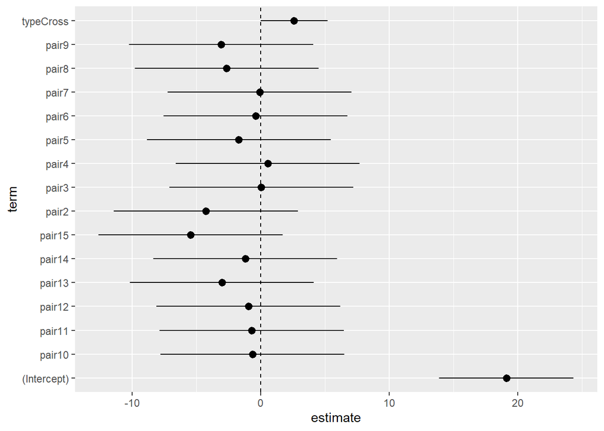

```r
tidymodel2 %>%
  ggplot(aes(x=estimate,
             y=term))+
  geom_pointrange(aes(xmin=conf.low,
                      xmax=conf.high))+
  geom_vline(xintercept=0,
             linetype="dashed")
```

**Q. Compare the confidence intervals for tidymodel1 and tidymodel2 - Why do you think they are not quite the same?**

- As we discussed in the lectures 95% CI are approximately 2 * S.E. if the assumption of a normal or z distribution is true.
- Sample sizes <30 become increasingly further away from the z distribution and follow the t distribution instead. When R calculates CI probabilities it uses the exact t distribution for the sample size.
- We can manually calculate the appropriate *t* for ourselves (though we don’t have to). So that we better understand how sample size can affect our ability to make accurate predictions.

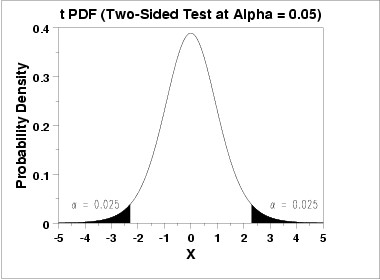

```r
knitr::include_graphics("img/tpdftb.jpg")
```

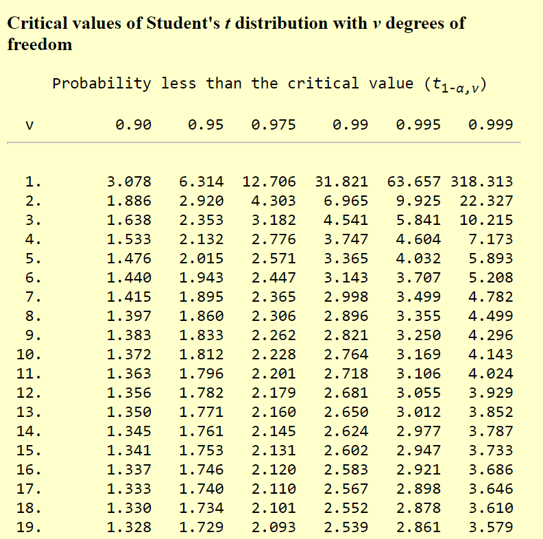

```r
knitr::include_graphics("img/t-dist.png")
```

```r
t.crit <- qt(0.975, df=14)

upr <- 2.62+t.crit*1.22
lwr <- 2.62-t.crit*1.22
```

# Reporting

## TASK 6: Use the Confidence intervals for mean DIFFERENCE to write up these results

Note:

- Pairs was included as a fixed effect to account for the paired-experiment design
- we are interested in the type~height relationship
- The confidence intervals of the mean *difference* allows us to talk about the *effect size*

**Check here for my attempt**

A paired t-test showed that the cross-pollinated maize were significantly taller than the self-pollinated plants by an average of 2.6 inches (95% CI: 0.004-5.23).

- Why no F-tests, df or P values? Well in theory this gives us the same qualititative information as we know that our 95% CI range is >0 so we can say that the difference in height is significant at P<0.05. And we are providing direct biological information about the estimated height difference.
- BUT most people will expect you to report F values, df, P values etc. so you should probably include them *as well*.
- A pairwise linear model showed that the cross-pollinated maize were significantly taller than the self-pollinated plants (*F*<sub>1,14</sub>= 4.61, *P* = 0.05) by an average of 2.6 inches (95% CI: 0.004-5.23).
- EFFECT SIZE: Finally although we know we have a significant height difference it is only by a very small margin (0.004 inches). In this way we can actually say we have 95% confidence that the height difference is *at least* 0.004 inches. If we wanted to we could estimate a range of confidence intervals e.g. we have 66% confidence that the height difference is at least 1.4 inches {confint(model, level=0.66)}.

# END

## Optional

**You should practice sending things to GitHub. You can upload this worksheet to your RStudio project workspace. You can then Stage, Commit & Push this worksheet (along with any Rscript you have written) to your repo for safekeeping.**

*Remember* There is also a comprehensive list of wider reading on the **Study Aids** Section of Blackboard.